# 1. **Problem statement**

# 4. Creating a Model for univariate linear regression

### Created 3 models with respect to dependent variable `median_house_value`

# Train the Model

### 1. `median_house_value` vs. `median_income`

### 2. `median_house_value` vs. `population`

### 3. `median_house_value` vs. `housholds`

# Table

##### Creating a table to store all the

##### 1. *Slope*

##### 2. *Intercept*

##### 3. *Mean Squared Error*

##### 4. *Mean Absolute Error*

```python
if "median_income" in train.columns and "population" in train.columns and "households" in train.columns:
    results = {
    "Model":[],
    "Intercept":[],
    "Slope":[],
    "mean_squared_error":[],
    "mean_absolute_error":[]
    }


    model_income = linear_model.LinearRegression()
    model_income.fit(train[["median_income"]], train[["median_house_value"]])

    y_predict_income = model_income.predict(train[["median_income"]])
    results["Model"].append("Median House Value vs Median Income")
    results["Intercept"].append(model_income.intercept_)
    results["Slope"].append(model_income.coef_)
    results["mean_squared_error"].append(mean_squared_error(train["median_house_value"], y_predict_income))
    results["mean_absolute_error"].append(mean_absolute_error(train["median_house_value"], y_predict_income))


    model_population = linear_model.LinearRegression()
    model_population.fit(train[["population"]], train[["median_house_value"]])

    y_predict_population = model_population.predict(train[["population"]])
    results["Model"].append("Median House Value vs Population")
    results["Intercept"].append(model_population.intercept_)
    results["Slope"].append(model_population.coef_)
    results["mean_squared_error"].append(mean_squared_error(train["median_house_value"], y_predict_population))
    results["mean_absolute_error"].append(mean_absolute_error(train["median_house_value"], y_predict_population))

    model_households = linear_model.LinearRegression()
    model_households.fit(X=train[["households"]], y=train[["median_house_value"]])

    y_predict_households = model_households.predict(train[["households"]])
    results["Model"].append("Median House Value vs Households")
    results["Intercept"].append(model_households.intercept_)
    results["Slope"].append(model_households.coef_)
    results["mean_squared_error"].append(mean_squared_error(train["median_house_value"], y_predict_households))
    results["mean_absolute_error"].append(mean_absolute_error(train["median_house_value"], y_predict_households))

    results_Df = pd.DataFrame(results)

    print(results_Df)

else:
    print("Required columns are missing in training data")
```

```
                                 Model             Intercept  \
0  Median House Value vs Median Income  [48204.534368169785]
1     Median House Value vs Population  [188081.58862583563]
2     Median House Value vs Households  [177147.28853834848]

                    Slope  mean_squared_error  mean_absolute_error
0   [[38702.97233842378]]        5.557954e+09         55839.998641
1  [[0.3286297271249774]]        9.236186e+09         75879.526606
2  [[22.625725908661156]]        9.156895e+09         75463.106515
```

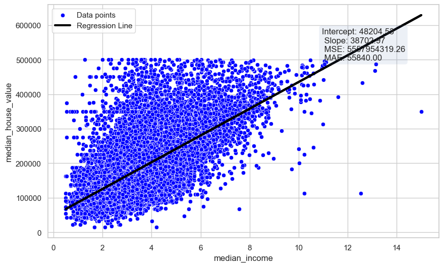

```python
# plot the regression line against the training data
plt.figure(figsize=(10, 6))

sns.scatterplot(x="median_income", y="median_house_value", data=train, color="blue", label = "Data points")
plt.plot(train[["median_income"]], model_income.predict(train[["median_income"]]), color="black", linewidth=3, label = "Regression Line")

textstr = f'Intercept: {model_income.intercept_[0]:.2f}\n Slope: {model_income.coef_[0][0]:.2f}\n MSE: {mean_squared_error(train["median_house_value"], y_predict_income):.2f}\n MAE: {mean_absolute_error(train["median_house_value"], y_predict_income):.2f}'
plt.gca().add_artist(plt.Text(0.7, 0.9, textstr, transform=plt.gca().transAxes, fontsize=12,
                               verticalalignment='top', bbox=dict(boxstyle='round', alpha=0.1)))

plt.legend()
plt.show()
```

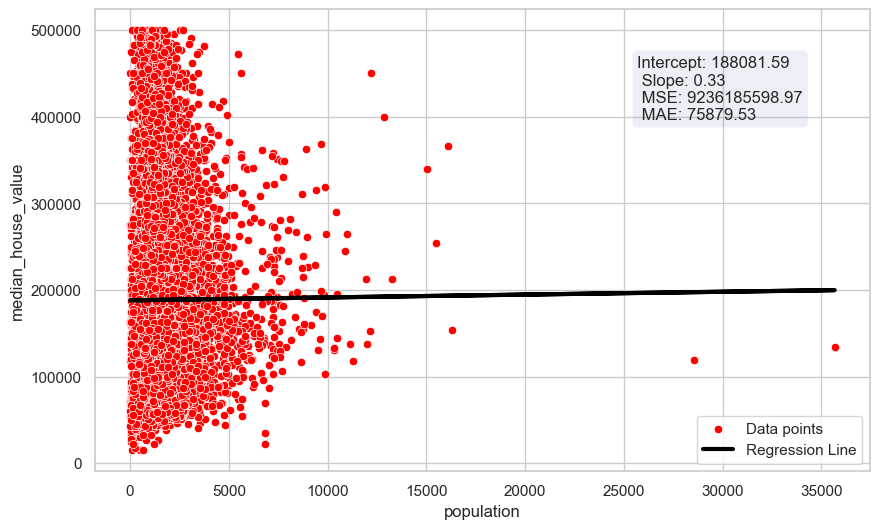

```python
plt.figure(figsize=(10, 6))

sns.scatterplot(x="population", y="median_house_value", data=train, color="red", label = "Data points")
plt.plot(train[["population"]], model_population.predict(train[["population"]]), color="black", linewidth=3, label = "Regression Line")

textstr = f'Intercept: {model_population.intercept_[0]:.2f}\n Slope: {model_population.coef_[0][0]:.2f}\n MSE: {mean_squared_error(train["median_house_value"], y_predict_population):.2f}\n MAE: {mean_absolute_error(train["median_house_value"], y_predict_population):.2f}'
plt.gca().add_artist(plt.Text(0.7, 0.9, textstr, transform=plt.gca().transAxes, fontsize=12,
                               verticalalignment='top', bbox=dict(boxstyle='round', alpha=0.1)))

plt.legend()
plt.show()
```

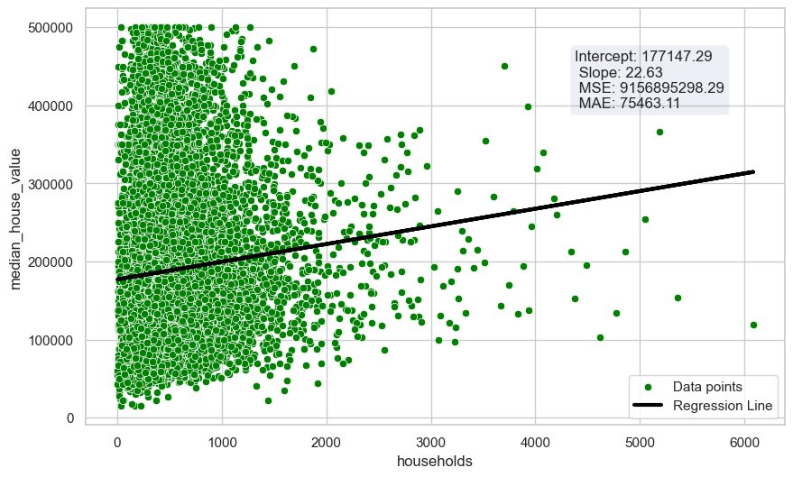

```python
plt.figure(figsize=(10, 6))
sns.scatterplot(x="households", y="median_house_value", data=train, color="green", label = "Data points")
plt.plot(train[["households"]], model_households.predict(train[["households"]]), color="black", linewidth=3, label = "Regression Line" )

textstr = f'Intercept: {model_households.intercept_[0]:.2f}\n Slope: {model_households.coef_[0][0]:.2f}\n MSE: {mean_squared_error(train["median_house_value"], y_predict_households):.2f}\n MAE: {mean_absolute_error(train["median_house_value"], y_predict_households):.2f}'
plt.gca().add_artist(plt.Text(0.7, 0.9, textstr, transform=plt.gca().transAxes, fontsize=12,
                               verticalalignment='top', bbox=dict(boxstyle='round', alpha=0.1)))

plt.legend()
plt.show()
```

# Summary

| Model | Intercept | Slope | Mean Squared Error | Mean Absolute Error |
| --- | --- | --- | --- | --- |
| Median House Value vs Median Income | 48204.53 | 38702.97 | 5.56e+09 | 55840.00 |
| Median House Value vs Population | 188081.59 | 0.33 | 9.24e+09 | 75879.53 |
| Median House Value vs Households | 177147.29 | 22.63 | 9.16e+09 | 75463.11 |

# Conclusion

##### Best model considered out of 3 above models was `median_house_value` vs. `median_income`. Outstanding features out of other models are as follows:

##### - Has lowest Mean Squared Error and Mean Absolute Error meaning better variance and less sensitive to outliers.

##### - Coefficient(*Slope*) is 38702.97 suggest strongest relationship of significant elevation between two variables

# Additional insights

##### Further features including `house_median_age`, `longitude`, `latitude` and other house related constraints could enhance our predictions which ultimately helps in better accuracy.